# Regression Models Project - Motor Trend Data = ‘mtcars’ Miles Per Gallon Analysis

```r
date()
```

[1] “Thu Dec 29 06:12:09 2016”

# Raw Data:

```
    Load the data from the dataset package & check
    for missing values. Overview: Motor Trend 'mtcars' data set:
```

```r
library(car);library(dplyr);library(MASS);data("mtcars");any(is.na(mtcars))
```

[output not shown]

A data frame with 32 observations on 11 variables.

[, 1] mpg Miles/(US) gallon  
[, 2] cyl Number of cylinders (4,6,8)  
[, 3] disp Displacement (cu.in.)  
[, 4] hp Gross horsepower  
[, 5] drat Rear axle ratio  
[, 6] wt Weight (1000 lbs)  
[, 7] qsec 1/4 mile time  
[, 8] vs V/S (0 = vee-block, 1 = straight-block)  
[, 9] am Transmission (0 = automatic, 1 = manual)  
[,10] gear Number of forward gears (3:5)  
[,11] carb Number of carburetors (1:4,6,8)

# Processed Data:

```
    Factor columns 2 & 8:11 (cyl,vs,am,gear,carb) into levels
```

```r
data("mtcars")
for(i in c(2,8:11))mtcars[,i] <- as.factor(mtcars[,i]);
str(mtcars)
```

[output not shown]

# Descriptive Statistics:

```r
library(datasets);library(dplyr);data("mtcars")
head(mtcars,4);mean(mtcars$mpg);sd(mtcars$mpg)
round(t.test(mtcars$mpg ~ am, data = mtcars,
             var.equal =FALSE, paired = FALSE, conf.level = 0.95 )$conf.int,3)
```

[output not shown]

# Exploratory Analysis:

```
    See Appendix A. Figures (pairs-plot, histogram, box-plot)
```

# Statistical Modeling:

```
    Multivarite Linear Model Finding Best Fit with Step function:
```

```r
library(stats);library(MASS);library(dplyr);data("mtcars")
fstp <- lm(mpg ~ ., data = mtcars)
stp <- step(fstp, trace = FALSE)
summary(stp)$r.squared
anova(stp)
```

[output not shown]

# Multivarite Linear Model Finding Best Fit with Step function:

```r
library(stats);library(MASS);library(ggplot2)
fstp <- lm(mpg ~ ., data = mtcars)
stp <- step(fstp, trace = FALSE)
coef(summary(stp))
summary(stp)$r.squared
x <- (mtcars$wt + mtcars$qsec + mtcars$am)
par(mfrow = c(1, 1), mar = c(4,4,4,2))
g <- ggplot(mtcars, aes(x = x, y = mpg),)
g <- g + xlab("Model stp = (wt + qsec + am)")
g <- g + ylab("Miles per Gallon")
g <- g + geom_smooth(aes(method = "lm", shape = factor(am)))
g <- g + geom_point(aes(shape = factor(am), size=qsec, colour=wt))
g
```

[output not shown]

# Diagnostics:

```r
x <- (mtcars$wt + mtcars$qsec + as.numeric(mtcars$am))
y <- mtcars$mpg
n <- length(y)
fw <- lm(y ~ x, data = mtcars)
e <- resid(fw);sum(e)
```

[1] 5.995204e-15

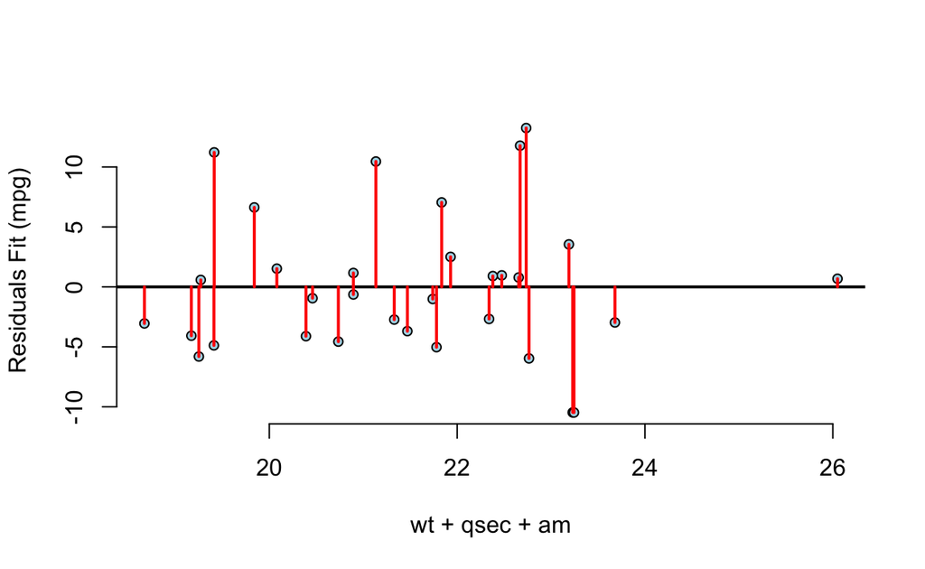

```r
#par(mfrow = c(1,1), mar = c(4,4,4,3)) # set margin
plot(x,e,
     xlab = "wt + qsec + am",
     ylab = "Residuals Fit (mpg)",
     bg = "lightblue",
     col = "black", cex = .85, pch = 21, frame = FALSE)
abline(h = 0, lwd = 2)
for(i in 1:n)
        lines(c(x[i], x[i]), c(e[i], 0), col = "red", lwd = 2)
```

```r
sum(e)
```

[1] 5.995204e-15

# Hypothesis Test:

```
            H0 = mean(mpg[am==automatic])  =   mean(mpg[am==manual]) (REJECT)
            Ha = mean(automatic transmission)mpg  !=  mean(manual transmission)mpg (ACCEPT)
```

```r
t.test(mpg ~ factor(am), paired = FALSE, var.equal=FALSE, data = mtcars)
```

```
Welch Two Sample t-test
```

data: mpg by factor(am) t = -3.7671, df = 18.332, p-value = 0.001374 alternative hypothesis: true difference in means is not equal to 0 95 percent confidence interval: -11.280194 -3.209684 sample estimates: mean in group 0 mean in group 1 17.14737 24.39231

# Appendix A: Figures: Exploratory Analysis

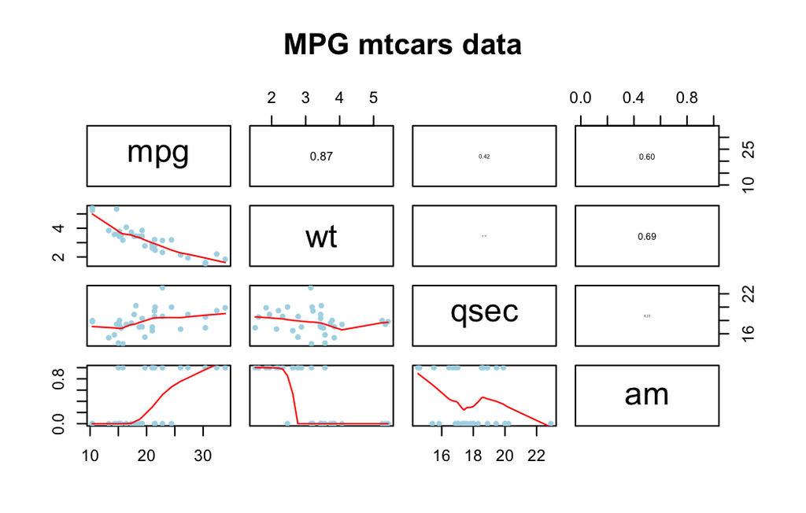

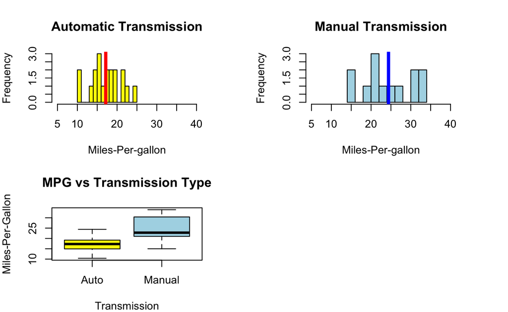